# Predicting Customer Churn in E-Commerce: Leveraging Statistical Models and Hypothesis Testing for Strategic Customer Segmentation and Marketing Optimization

Nikkat Afrin

# Abstract

This project investigates the key factors influencing customer churn in an e-commerce environment and explores how statistical models can be used to predict churn and optimize marketing strategies. The dataset, generated using the Faker Python library, simulates customer transactions, demographics, and churn behavior. Exploratory Data Analysis (EDA) revealed uniform distributions across most numerical variables, with a class imbalance in the churn variable, where 80% of customers were non-churned. Chi-Squared tests identified a significant relationship between Payment. Method and churn, while other categorical variables showed no strong associations. T-tests for numerical variables like Product.Price and Customer. Age indicated minimal differences between churned and non-churned customers.

A logistic regression model was employed to predict churn, using features such as Product. Price, Quantity, Total.Purchase.Amount, Customer.Age, and Returns. Oversampling was applied to address the class imbalance, ensuring equal representation of churned and non-churned customers in the training data. Despite these efforts, the model achieved an accuracy of ~50% and an ROC AUC of ~0.5, suggesting poor predictive performance. The results highlight weak relationships between the features and churn, limiting the model’s generalization ability.

The analysis underscores the limitations of synthetic data, which lacks the complexity and patterns of real-world e-commerce data. While the applied methods—including EDA, hypothesis testing, and logistic regression—were appropriate, the lack of meaningful feature relationships and the artificial nature of the data hindered the model’s effectiveness. Future work should focus on real-world datasets with richer features, such as customer engagement metrics and satisfaction scores, and explore advanced models like Random Forests or Gradient Boosting. Despite its limitations, this study provides a framework for analyzing churn and demonstrates the challenges of modeling using synthetic data.

# Dataset Overview

## Data Collection:

The data for this project, called the “E-commerce Customer Behavior and Purchase Dataset,” was taken from Kaggle. It is a synthetic dataset, which means it was created artificially using a tool called the Faker Python library. The dataset is designed to look like real e-commerce data and includes details about customer behavior and purchase history in an online marketplace. This data is useful for tasks such as predicting customer churn, analyzing product purchases, creating recommendation systems, and studying trends in customer activity.

## Variables:

###1. Response Variable

The response variable in this dataset is **Churn**. It is a **categorical** variable indicating whether a customer has churned (1) or is retained (0). This variable is important because it helps us understand customer retention, and we can use it in predictive models to analyze factors influencing churn.

###2. Explanatory Variables

The explanatory variables are all other columns that provide information about the customer’s demographics, purchasing behavior, and engagement with the platform. These include:

- **Customer Age**: Numerical
- **Gender**: Categorical
- **Product Category**: Categorical
- **Product Price**: Numerical
- **Quantity**: Numerical
- **Total Purchase Amount**: Numerical
- **Payment Method**: Categorical
- **Returns**: Categorical (binary)

# Research Question

**What are the key factors that predict customer churn in an e-commerce environment, and how can statistical models, including hypothesis testing and regression analysis, be used to identify these factors and optimize marketing strategies?**

# Data Preprocessing

```r
library(tidyverse)
```

## Data Loading:

```r
# Load data from GitHub
github_url <- "https://raw.githubusercontent.com/Nikkat-Afrin/Customer-Segmentation-and-Marketing-Optimization-in-E-Commerce/refs/heads/main/ecommerce_customer_data_large.csv"
ecommerce_data <- read.csv(github_url)
head(ecommerce_data)  # Check the first few rows
```

```
##   Customer.ID       Purchase.Date Product.Category Product.Price Quantity
## 1       44605 2023-05-03 21:30:02             Home           177        1
## 2       44605 2021-05-16 13:57:44      Electronics           174        3
## 3       44605 2020-07-13 06:16:57            Books           413        1
## 4       44605 2023-01-17 13:14:36      Electronics           396        3
## 5       44605 2021-05-01 11:29:27            Books           259        4
## 6       13738 2022-08-25 06:48:33             Home           191        3
##   Total.Purchase.Amount Payment.Method Customer.Age Returns  Customer.Name Age
## 1                  2427         PayPal           31       1    John Rivera  31
## 2                  2448         PayPal           31       1    John Rivera  31
## 3                  2345    Credit Card           31       1    John Rivera  31
## 4                   937           Cash           31       0    John Rivera  31
## 5                  2598         PayPal           31       1    John Rivera  31
## 6                  3722    Credit Card           27       1 Lauren Johnson  27
##   Gender Churn
## 1 Female     0
## 2 Female     0
## 3 Female     0
## 4 Female     0
## 5 Female     0
## 6 Female     0
```

##Data Structure of the Variables in the data set:

```r
# Checking data structure
str(ecommerce_data)
```

```
## 'data.frame':    250000 obs. of  13 variables:
##  $ Customer.ID          : int  44605 44605 44605 44605 44605 13738 13738 13738 13738 13738 ...
##  $ Purchase.Date        : chr  "2023-05-03 21:30:02" "2021-05-16 13:57:44" "2020-07-13 06:16:57" "2023-01-17 13:14:36" ...
##  $ Product.Category     : chr  "Home" "Electronics" "Books" "Electronics" ...
##  $ Product.Price        : int  177 174 413 396 259 191 205 370 12 40 ...
##  $ Quantity             : int  1 3 1 3 4 3 1 5 2 4 ...
##  $ Total.Purchase.Amount: int  2427 2448 2345 937 2598 3722 2773 1486 2175 4327 ...
##  $ Payment.Method       : chr  "PayPal" "PayPal" "Credit Card" "Cash" ...
##  $ Customer.Age         : int  31 31 31 31 31 27 27 27 27 27 ...
##  $ Returns              : num  1 1 1 0 1 1 NA 1 NA 0 ...
##  $ Customer.Name        : chr  "John Rivera" "John Rivera" "John Rivera" "John Rivera" ...
##  $ Age                  : int  31 31 31 31 31 27 27 27 27 27 ...
##  $ Gender               : chr  "Female" "Female" "Female" "Female" ...
##  $ Churn                : int  0 0 0 0 0 0 0 0 0 0 ...
```

```r
# response variable
table(ecommerce_data$Churn)
```

```
##
##      0      1
## 199870  50130
```

## Checking for the Missing Values:

```r
# Percentage of missing values by column
missing_summary <- data.frame(
  Column = colnames(ecommerce_data),
  Missing_Values = colSums(is.na(ecommerce_data)),
  Percentage = colSums(is.na(ecommerce_data)) / nrow(ecommerce_data) * 100
)

print(missing_summary)
```

```
##                                      Column Missing_Values Percentage
## Customer.ID                     Customer.ID              0     0.0000
## Purchase.Date                 Purchase.Date              0     0.0000
## Product.Category           Product.Category              0     0.0000
## Product.Price                 Product.Price              0     0.0000
## Quantity                           Quantity              0     0.0000
## Total.Purchase.Amount Total.Purchase.Amount              0     0.0000
## Payment.Method               Payment.Method              0     0.0000
## Customer.Age                   Customer.Age              0     0.0000
## Returns                             Returns          47382    18.9528
## Customer.Name                 Customer.Name              0     0.0000
## Age                                     Age              0     0.0000
## Gender                               Gender              0     0.0000
## Churn                                 Churn              0     0.0000
```

As we can see in the Returs column we have total of 47382 missing value which corresponds to 18.9% of the data values in that column.

## Handling Missing Values: Removing the rows with missing values in the dataset

```r
ecommerce_data <- ecommerce_data[complete.cases(ecommerce_data$Returns), ]
```

## Check for missing values:

```r
# Check if there are any missing values in the Returns column
sum(is.na(ecommerce_data$Returns))
```

```
## [1] 0
```

```r
# Check the number of rows and columns
dim(ecommerce_data)
```

```
## [1] 202618     13
```

## Data Cleaning

### Updating Total Purchase Amount Column

The `Total Purchase Amount` column in the dataset was found to have incorrect values. This issue was resolved by recalculating the column as the product of `Product Price` and `Quantity`. The updated column was generated within the R environment without modifying the original dataset on GitHub.

```r
# Update the 'Total Purchase Amount' column
ecommerce_data$Total.Purchase.Amount <- ecommerce_data$Product.Price * ecommerce_data$Quantity

# Display the updated dataset
head(ecommerce_data)  # Display the first few rows
```

```
##   Customer.ID       Purchase.Date Product.Category Product.Price Quantity
## 1       44605 2023-05-03 21:30:02             Home           177        1
## 2       44605 2021-05-16 13:57:44      Electronics           174        3
## 3       44605 2020-07-13 06:16:57            Books           413        1
## 4       44605 2023-01-17 13:14:36      Electronics           396        3
## 5       44605 2021-05-01 11:29:27            Books           259        4
## 6       13738 2022-08-25 06:48:33             Home           191        3
##   Total.Purchase.Amount Payment.Method Customer.Age Returns  Customer.Name Age
## 1                   177         PayPal           31       1    John Rivera  31
## 2                   522         PayPal           31       1    John Rivera  31
## 3                   413    Credit Card           31       1    John Rivera  31
## 4                  1188           Cash           31       0    John Rivera  31
## 5                  1036         PayPal           31       1    John Rivera  31
## 6                   573    Credit Card           27       1 Lauren Johnson  27
##   Gender Churn
## 1 Female     0
## 2 Female     0
## 3 Female     0
## 4 Female     0
## 5 Female     0
## 6 Female     0
```

```r
# Optional: Summary of the updated column
summary(ecommerce_data$Total.Purchase.Amount)
```

```
##    Min. 1st Qu.  Median    Mean 3rd Qu.    Max.
##    10.0   290.0   606.0   767.5  1140.0  2500.0
```

# Exploratory Data Analysis

### Explanatory Variables

To understand the explanatory variables better, we generated the summary statistics and organized them in a table for easier readability.

```r
# explanatory variables
summary(ecommerce_data[c("Customer.Age", "Gender", "Product.Category", "Product.Price", "Quantity", "Total.Purchase.Amount", "Payment.Method", "Returns")])
```

```
##   Customer.Age      Gender          Product.Category   Product.Price
##  Min.   :18.00   Length:202618      Length:202618      Min.   : 10.0
##  1st Qu.:30.00   Class :character   Class :character   1st Qu.:133.0
##  Median :44.00   Mode  :character   Mode  :character   Median :255.0
##  Mean   :43.82                                         Mean   :254.9
##  3rd Qu.:57.00                                         3rd Qu.:377.0
##  Max.   :70.00                                         Max.   :500.0
##     Quantity     Total.Purchase.Amount Payment.Method        Returns
##  Min.   :1.000   Min.   :  10.0        Length:202618      Min.   :0.0000
##  1st Qu.:2.000   1st Qu.: 290.0        Class :character   1st Qu.:0.0000
##  Median :3.000   Median : 606.0        Mode  :character   Median :1.0000
##  Mean   :3.008   Mean   : 767.5                           Mean   :0.5008
##  3rd Qu.:4.000   3rd Qu.:1140.0                           3rd Qu.:1.0000
##  Max.   :5.000   Max.   :2500.0                           Max.   :1.0000
```

## Univariate Analysis:

### Numerical Variables

1. **Customer Age**:  
   Ages range from 18 to 70, with an average age of about 43.8. The median and mean are close.

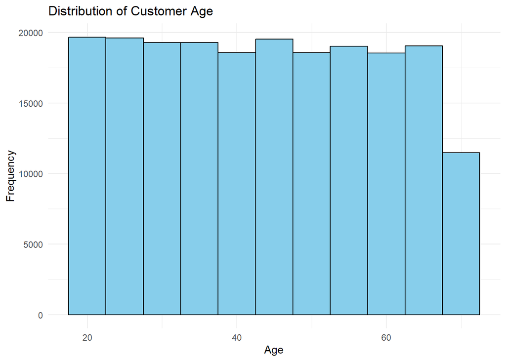

```r
library(ggplot2)

# Plotting Customer Age Distribution
ggplot(ecommerce_data, aes(x = Customer.Age)) +
  geom_histogram(binwidth = 5, fill = "skyblue", color = "black") +
  labs(title = "Distribution of Customer Age", x = "Age", y = "Frequency") +
  theme_minimal()
```

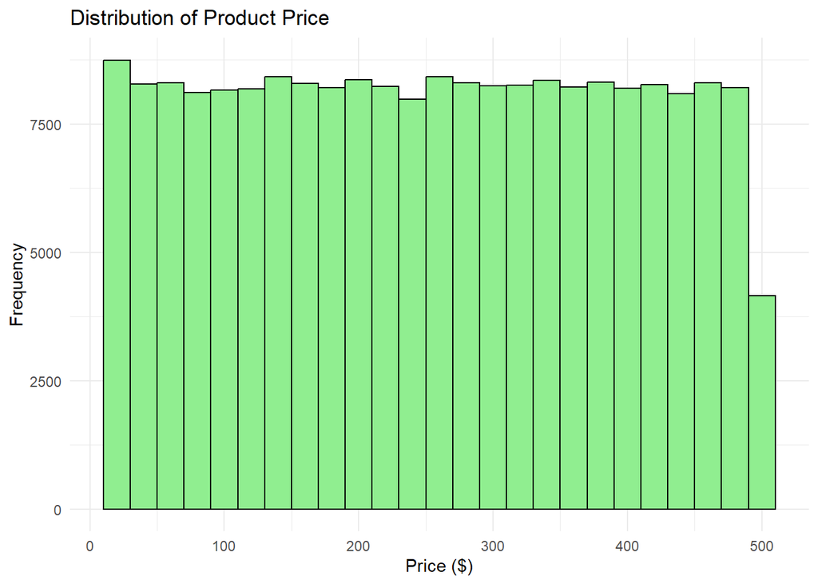

```r
# Plotting Product Price Distribution
ggplot(ecommerce_data, aes(x = Product.Price)) +
  geom_histogram(binwidth = 20, fill = "lightgreen", color = "black") +
  labs(title = "Distribution of Product Price", x = "Price ($)", y = "Frequency") +
  theme_minimal()
```

3. **Quantity**:  
   Quantities per transaction range from 1 to 5, with an average close to 3, showing that customers typically purchase around 2-4 items per transaction.

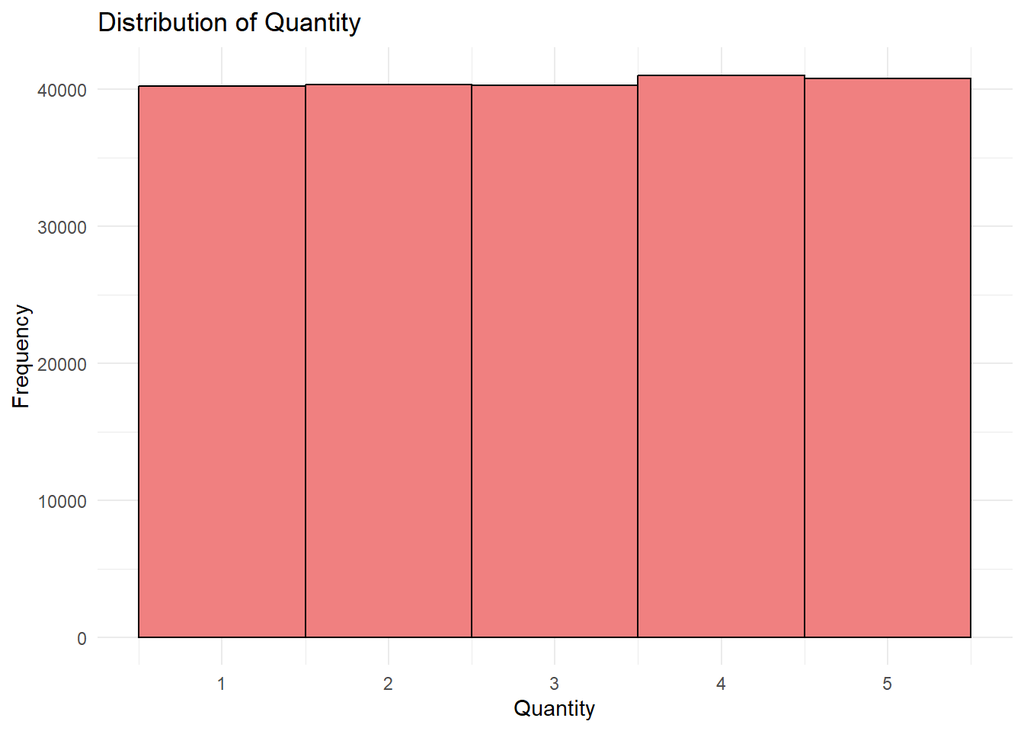

```r
# Plotting Quantity Distribution
ggplot(ecommerce_data, aes(x = Quantity)) +
  geom_histogram(binwidth = 1, fill = "lightcoral", color = "black") +
  labs(title = "Distribution of Quantity", x = "Quantity", y = "Frequency") +
  theme_minimal()
```

4. **Total Purchase Amount**:

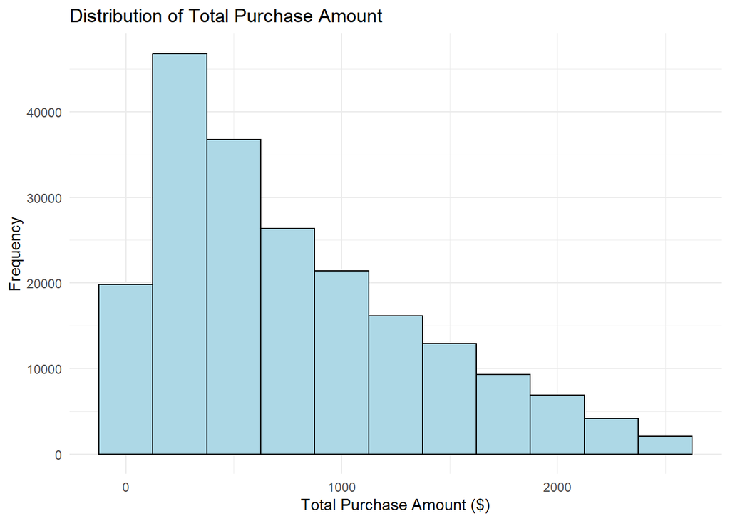

```r
# Plotting Total Purchase Amount Distribution
ggplot(ecommerce_data, aes(x = Total.Purchase.Amount)) +
  geom_histogram(binwidth = 250, fill = "lightblue", color = "black") +
  labs(title = "Distribution of Total Purchase Amount", x = "Total Purchase Amount ($)", y = "Frequency") +
  theme_minimal()
```

5. **Returns**:  
   The `Returns` column is binary (0 or 1), with approximately equal returns and non-returns. we already Handled the missing values during data preprocessing.

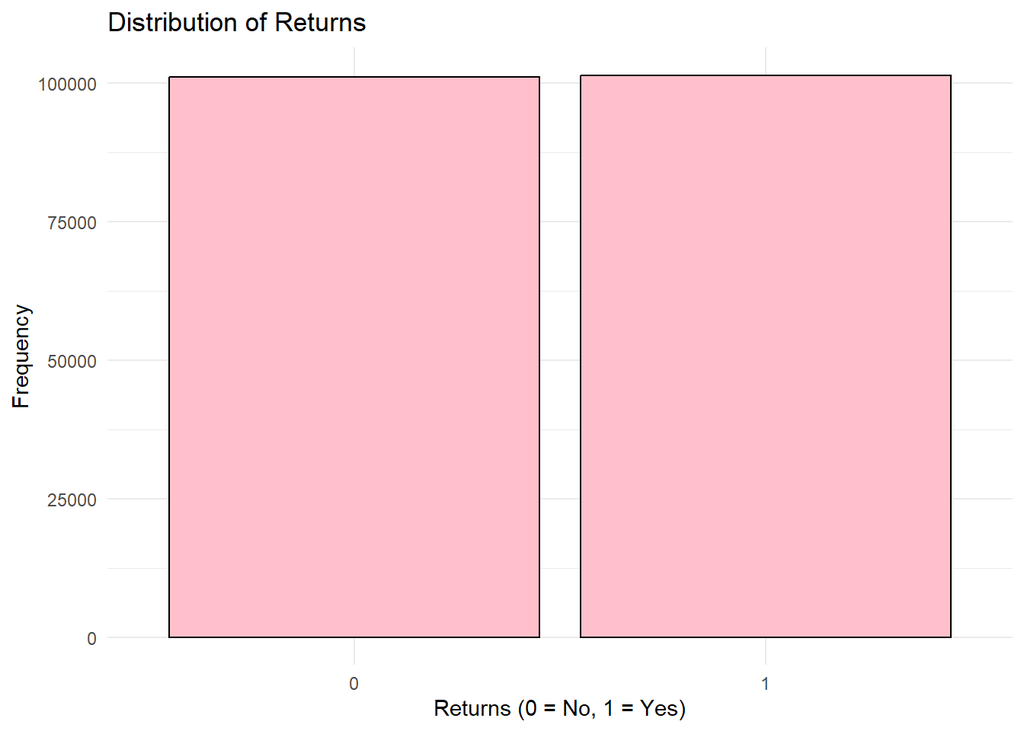

```r
# Plotting Returns Distribution (Binary)
ggplot(ecommerce_data, aes(x = factor(Returns))) +
  geom_bar(fill = "pink", color = "black") +
  labs(title = "Distribution of Returns", x = "Returns (0 = No, 1 = Yes)", y = "Frequency") +
  theme_minimal()
```

This bar chart shows the distribution of returns. Approximately 100,000 transactions each are labeled as “0” (no return) and “1” (return), indicating an equal balance of returns and non-returns.

6. **Churn**

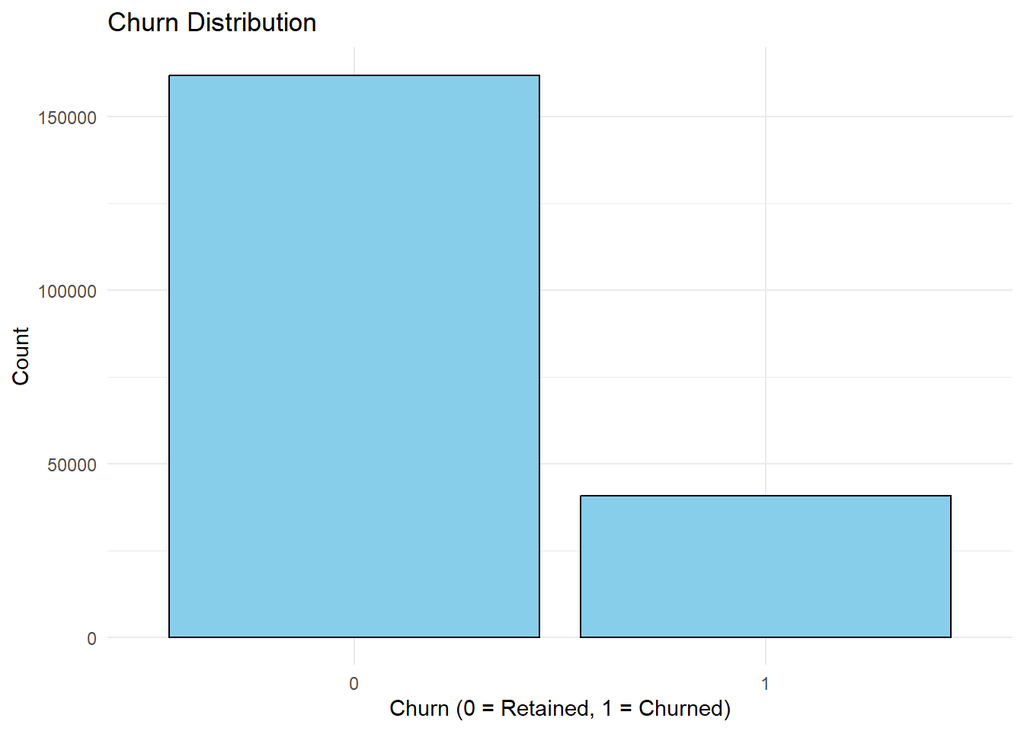

```r
ggplot(ecommerce_data, aes(x = factor(Churn))) +
  geom_bar(fill = "skyblue", color = "black") +
  labs(
    title = "Churn Distribution",
    x = "Churn (0 = Retained, 1 = Churned)",
    y = "Count"
  ) +
  theme_minimal()
```

- A significant majority of the customers are retained, as indicated by the taller bar for 0 (Retained). - A relatively smaller proportion of customers have churned, as shown by the shorter bar for 1 (Churned). - The disparity in the two bars highlights class imbalance in the dataset, with more retained customers compared to churned ones.

```r
library(dplyr)

# Count the occurrences of each value in the Churn column
ecommerce_data %>%
  count(Churn)
```

```
##   Churn      n
## 1     0 161874
## 2     1  40744
```

### Categorical Variables:

```r
library(dplyr)

# Frequency table for Gender
gender_freq <- ecommerce_data %>%
  group_by(Gender) %>%
  summarise(Frequency = n())

print("Frequency Table for Gender")
```

```
## [1] "Frequency Table for Gender"
```

```r
gender_freq
```

```
## # A tibble: 2 × 2
##   Gender Frequency
##   <chr>      <int>
## 1 Female    100699
## 2 Male      101919
```

```r
# Frequency table for Product Category
product_category_freq <- ecommerce_data %>%
  group_by(Product.Category) %>%
  summarise(Frequency = n())

print("Frequency Table for Product Category")
```

```
## [1] "Frequency Table for Product Category"
```

```r
product_category_freq
```

```
## # A tibble: 4 × 2
##   Product.Category Frequency
##   <chr>                <int>
## 1 Books                50419
## 2 Clothing             50754
## 3 Electronics          50704
## 4 Home                 50741
```

```r
# Frequency table for Payment Method
payment_method_freq <- ecommerce_data %>%
  group_by(Payment.Method) %>%
  summarise(Frequency = n())

print("Frequency Table for Payment Method")
```

```
## [1] "Frequency Table for Payment Method"
```

```r
payment_method_freq
```

```
## # A tibble: 3 × 2
##   Payment.Method Frequency
##   <chr>              <int>
## 1 Cash               67290
## 2 Credit Card        67517
## 3 PayPal             67811
```

## Summary statistics: categorical variables

1. **Gender**: The dataset includes 100699 female customers and 101919 male customers, showing a nearly balanced gender distribution.
2. **Product Category**: The product categories are evenly distributed, with each category (Books, Clothing, Electronics, Home) having around 50,000 purchases.
3. **Payment Method**: Payment methods are also evenly distributed, with Cash, Credit Card, and PayPal each used in roughly 67,000 transactions.

### Product Category Breakdown

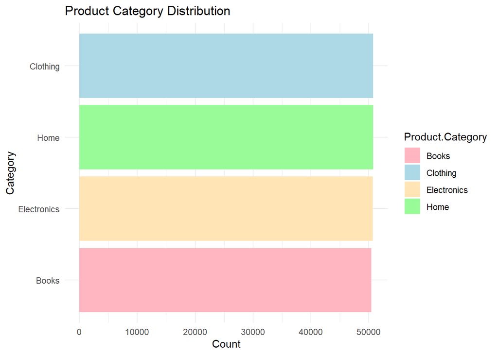

```r
ecommerce_data %>%
  group_by(Product.Category) %>%
  summarise(Count = n()) %>%
  ggplot(aes(x = reorder(Product.Category, Count), y = Count, fill = Product.Category)) +
  geom_bar(stat = "identity") +
  coord_flip() +
  scale_fill_manual(values = c("#FFB6C1", "#ADD8E6", "#FFE4B5", "#98FB98", "#FFD700")) +
  labs(
    title = "Product Category Distribution",
    x = "Category",
    y = "Count"
  ) +
  theme_minimal()
```

## Bivariate ANalysis:

#### **1. Bar Plot: Product Category and Churn:**

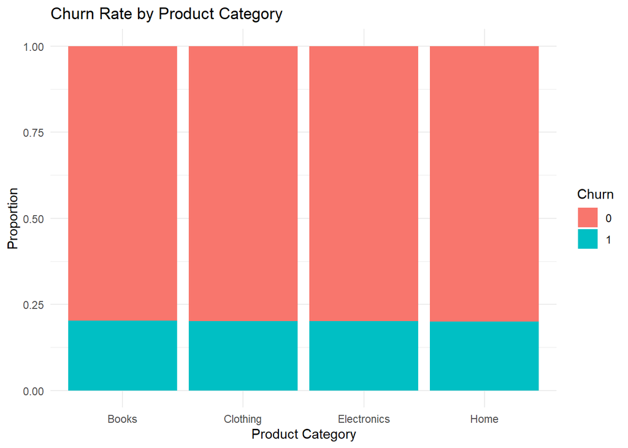

```r
ggplot(ecommerce_data, aes(x = Product.Category, fill = factor(Churn))) +
  geom_bar(position = "fill") +
  labs(
    title = "Churn Rate by Product Category",
    x = "Product Category",
    y = "Proportion",
    fill = "Churn"
  ) +
  theme_minimal()
```

The graph shows that churn rates (proportion of customers who left, labeled as 1) are consistent across all product categories, with churned customers comprising a smaller proportion compared to retained customers. This indicates that product category does not significantly influence churn behavior.

#### **1.2 Bar Plot: Payment.Method vs. Churn:**

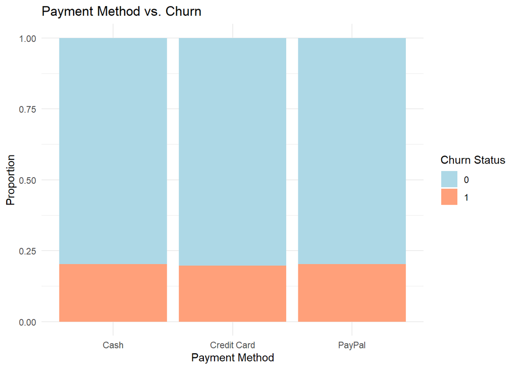

```r
ggplot(ecommerce_data, aes(x = Payment.Method, fill = factor(Churn))) +
  geom_bar(position = "fill") +
  labs(
    title = "Payment Method vs. Churn",
    x = "Payment Method",
    y = "Proportion",
    fill = "Churn Status"
  ) +
  scale_fill_manual(values = c("#ADD8E6", "#FFA07A")) +
  theme_minimal()
```

The graph indicates that churn rates (proportion of customers labeled as 1) are similar across all payment methods, with churned customers forming a smaller portion compared to retained customers. This suggests that payment method does not significantly influence churn behavior.

#### **1.3 Bar Plot: Returns vs. Churn:**

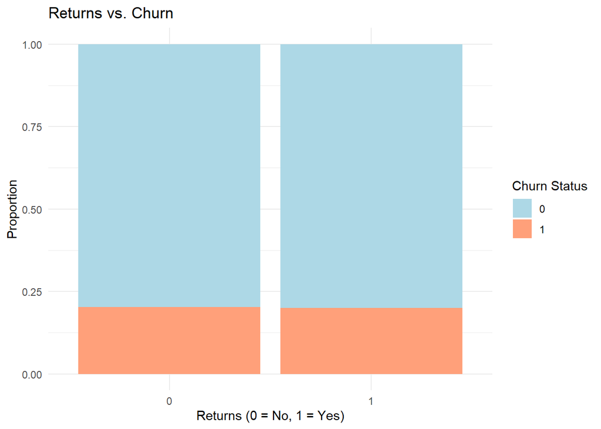

```r
ggplot(ecommerce_data, aes(x = factor(Returns), fill = factor(Churn))) +
  geom_bar(position = "fill") +
  labs(
    title = "Returns vs. Churn",
    x = "Returns (0 = No, 1 = Yes)",
    y = "Proportion",
    fill = "Churn Status"
  ) +
  scale_fill_manual(values = c("#ADD8E6", "#FFA07A")) +
  theme_minimal()
```

The graph shows that churn rates (proportion of customers labeled as 1) are nearly identical between customers who return products (1) and those who do not (0). This suggests that product returns have minimal impact on customer churn behavior.

#### **2. Box Plots**

##### **2.1 Price Variability by Product Category**

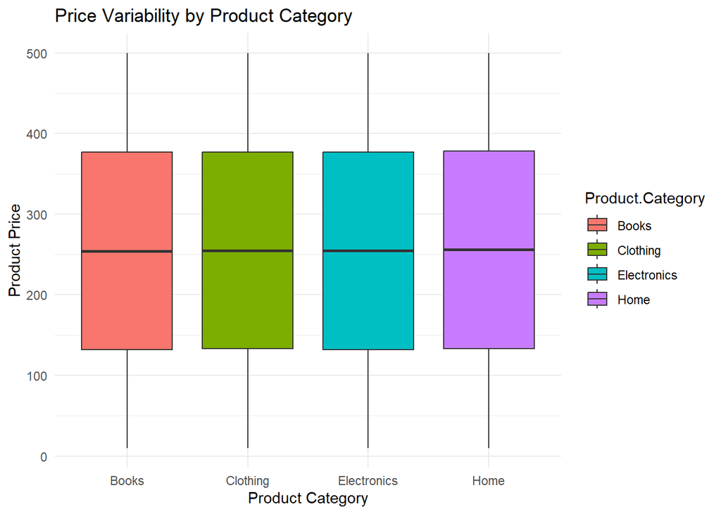

```r
ggplot(ecommerce_data, aes(x = Product.Category, y = Product.Price, fill = Product.Category)) +
  geom_boxplot() +
  labs(
    title = "Price Variability by Product Category",
    x = "Product Category",
    y = "Product Price"
  ) +
  theme_minimal()
```

##### **2.2 Quantity by Product Category**

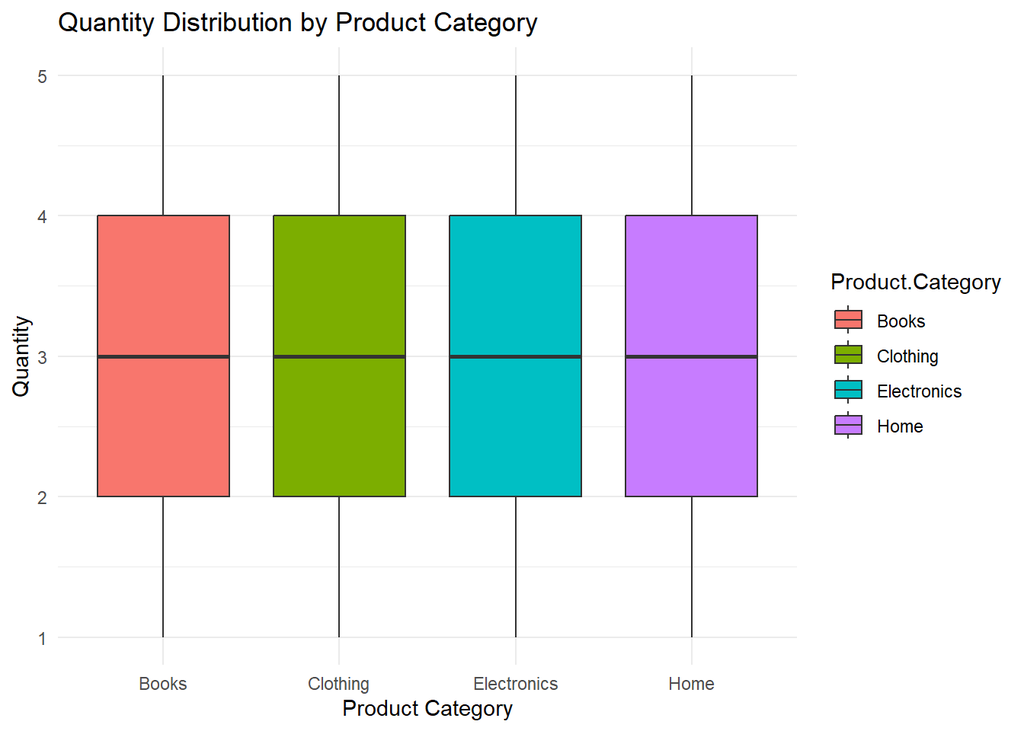

```r
ggplot(ecommerce_data, aes(x = Product.Category, y = Quantity, fill = Product.Category)) +
  geom_boxplot() +
  labs(
    title = "Quantity Distribution by Product Category",
    x = "Product Category",
    y = "Quantity"
  ) +
  theme_minimal()
```

##### **2.3 Total.Purchase.Amount by churn status**

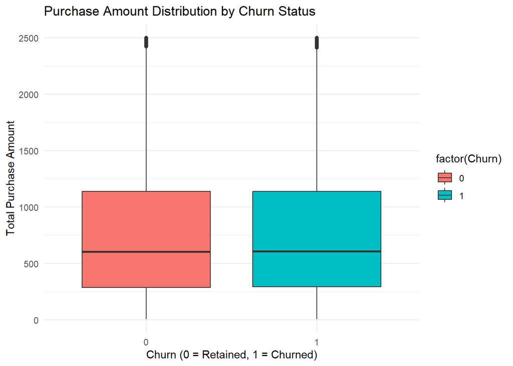

```r
ggplot(ecommerce_data, aes(x = factor(Churn), y = Total.Purchase.Amount, fill = factor(Churn))) +
  geom_boxplot() +
  labs(
    title = "Purchase Amount Distribution by Churn Status",
    x = "Churn (0 = Retained, 1 = Churned)",
    y = "Total Purchase Amount"
  ) +
  theme_minimal()
```

##### **2.4 Customer.Age vs. Churn**

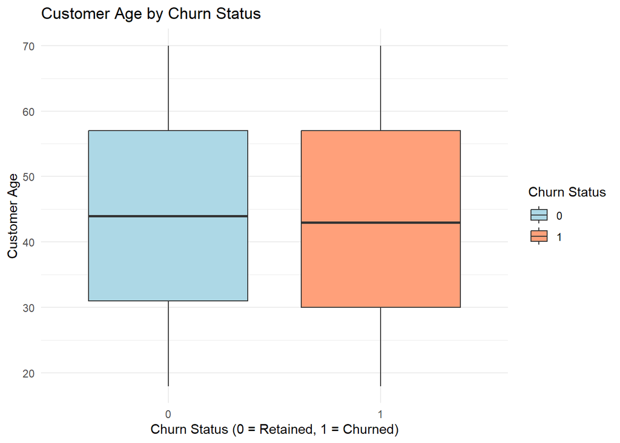

```r
ggplot(ecommerce_data, aes(x = factor(Churn), y = Customer.Age, fill = factor(Churn))) +
  geom_boxplot() +
  labs(
    title = "Customer Age by Churn Status",
    x = "Churn Status (0 = Retained, 1 = Churned)",
    y = "Customer Age"
  ) +
  scale_fill_manual(values = c("#ADD8E6", "#FFA07A"), name = "Churn Status") +
  theme_minimal()
```

##### **2.5 Product.Price vs. Churn**

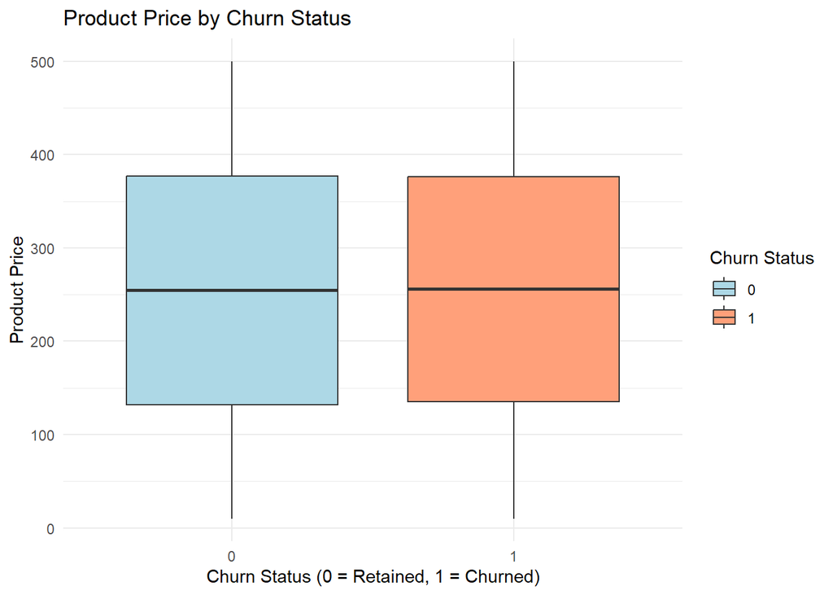

```r
ggplot(ecommerce_data, aes(x = factor(Churn), y = Product.Price, fill = factor(Churn))) +
  geom_boxplot() +
  labs(
    title = "Product Price by Churn Status",
    x = "Churn Status (0 = Retained, 1 = Churned)",
    y = "Product Price"
  ) +
  scale_fill_manual(values = c("#ADD8E6", "#FFA07A"), name = "Churn Status") +
  theme_minimal()
```

#### **3. Density Plots**

##### **3.1 Customer Age and Churn (Density Plot):

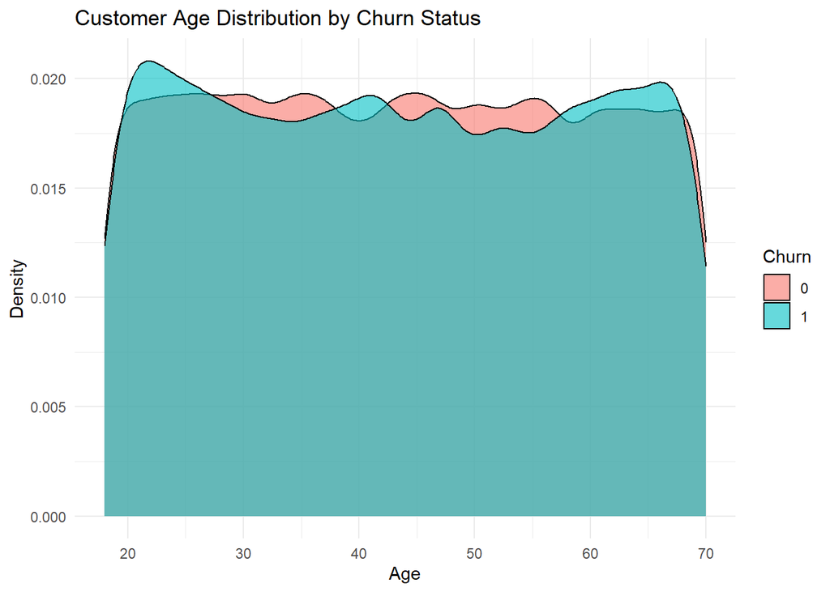

```r
ggplot(ecommerce_data, aes(x = Customer.Age, fill = factor(Churn))) +
  geom_density(alpha = 0.6) +
  labs(
    title = "Customer Age Distribution by Churn Status",
    x = "Age",
    y = "Density",
    fill = "Churn"
  ) +
  theme_minimal()
```

The density plot indicates that customers aged between 20 to 25 and 58 to 65 have higher churn rates compared to other age groups, as the distribution for churned customers (1) is more pronounced in these age ranges. This suggests that age might influence churn behavior in these specific groups.

##### **3.2 Product Price by Product Category**

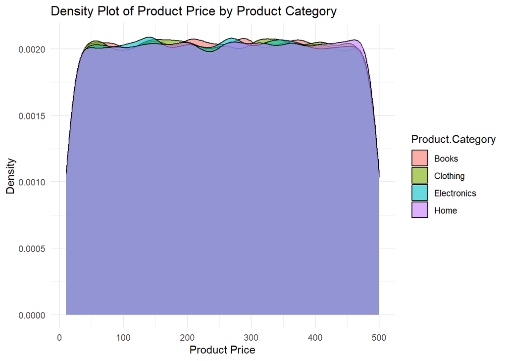

```r
ggplot(ecommerce_data, aes(x = Product.Price, fill = Product.Category)) +
  geom_density(alpha = 0.6) +
  labs(
    title = "Density Plot of Product Price by Product Category",
    x = "Product Price",
    y = "Density"
  ) +
  theme_minimal()
```

##### **3.2 Product.Price by Churn**

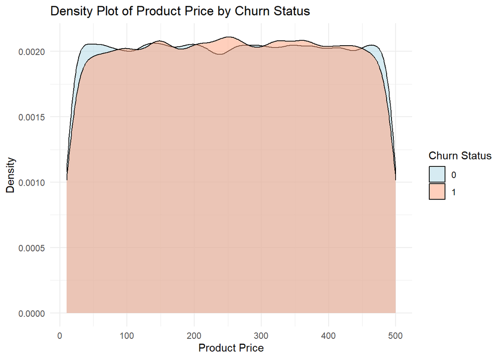

```r
ggplot(ecommerce_data, aes(x = Product.Price, fill = factor(Churn))) +
  geom_density(alpha = 0.5) +
  labs(
    title = "Density Plot of Product Price by Churn Status",
    x = "Product Price",
    y = "Density",
    fill = "Churn Status"
  ) +
  scale_fill_manual(values = c("#ADD8E6", "#FFA07A")) +
  theme_minimal()
```

This density plot for product price segmented by churn status shows nearly identical distributions for churned (1) and retained (0) customers. This suggests that product price has little to no influence on churn, as customers in both groups exhibit similar preferences across the price range.

#### **4.Correlation Heatmap**

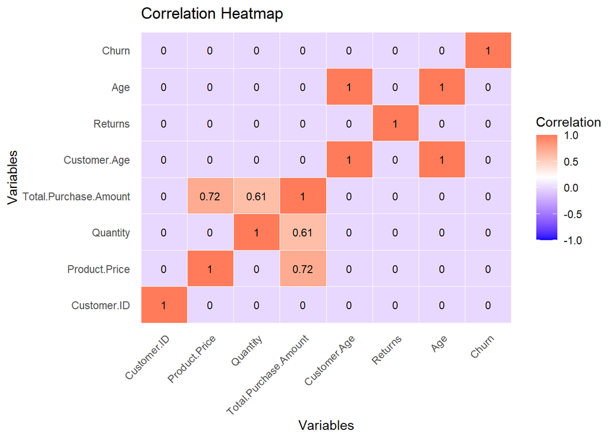

```r
# Compute Correlation Matrix
numeric_data <- ecommerce_data %>%
  select_if(is.numeric)
correlation_matrix <- cor(numeric_data, use = "complete.obs")

# Convert the matrix into a format suitable for ggplot2
correlation_data <- as.data.frame(as.table(correlation_matrix))
colnames(correlation_data) <- c("Variable1", "Variable2", "Correlation")

ggplot(correlation_data, aes(x = Variable1, y = Variable2, fill = Correlation)) +
  geom_tile(color = "white") +  # Add white borders for better visibility
  scale_fill_gradient2(low = "blue", high = "red", mid = "white", midpoint = 0.2,
                       limits = c(-1, 1), space = "Lab", name = "Correlation") +
  geom_text(aes(label = round(Correlation, 2)), color = "black", size = 3) +  # Add numeric values
  labs(
    title = " Correlation Heatmap",
    x = "Variables",
    y = "Variables"
  ) +
  theme_minimal() +
  theme(
    axis.text.x = element_text(angle = 45, hjust = 1),  # Rotate x-axis labels
    panel.grid = element_blank()  # Remove gridlines for a cleaner look
  )
```

This heatmap visualizes the correlations among the numerical variables in your dataset.

## MultiVariate Analysis:

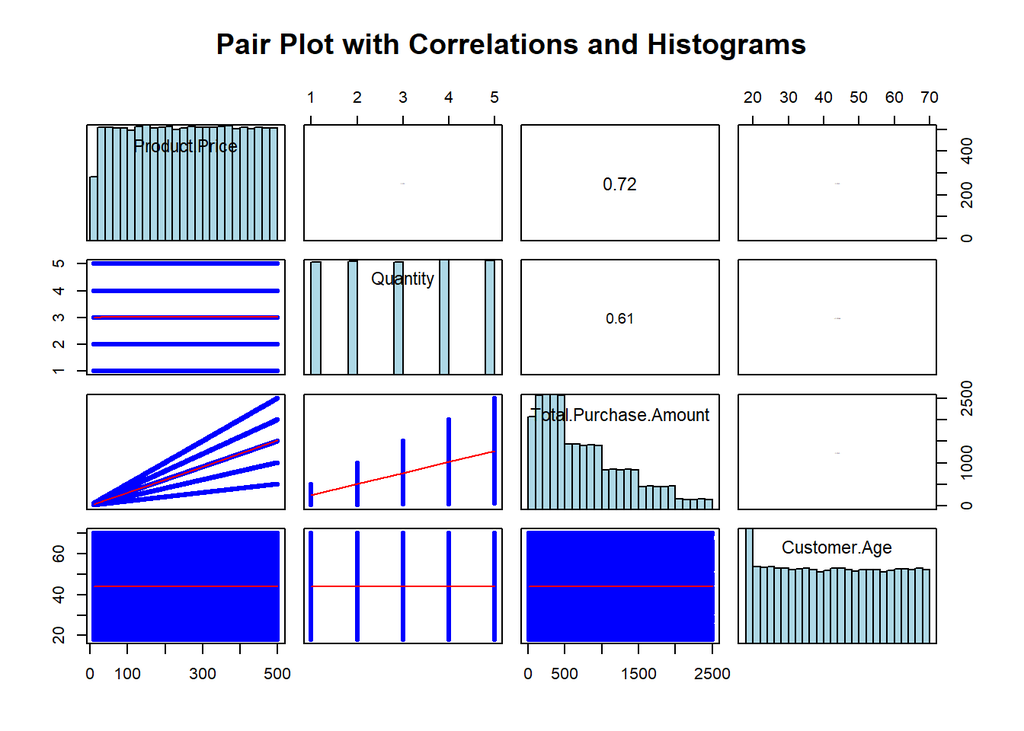

```r
# Subset the relevant numerical columns from your dataset
numerical_data <- ecommerce_data[, c("Product.Price", "Quantity", "Total.Purchase.Amount", "Customer.Age")]

# Custom function to display correlation in the upper panel
panel.cor <- function(x, y, digits = 2, prefix = "", cex.cor = 1.5, ...) {
  usr <- par("usr"); on.exit(par(usr))  # Save and reset user coordinates
  par(usr = c(0, 1, 0, 1))  # Set user coordinates for the panel
  r <- cor(x, y, use = "complete.obs")
  txt <- format(c(r, 0.123456789), digits = digits)[1]
  txt <- paste0(prefix, txt)
  text(0.5, 0.5, txt, cex = cex.cor * abs(r))  # Add the correlation value
}

# Custom function to display histograms on the diagonal
panel.hist <- function(x, ...) {
  usr <- par("usr"); on.exit(par(usr))  # Save and reset user coordinates
  par(usr = c(usr[1:2], 0, 1))  # Set y-axis to 0-1 for histogram
  h <- hist(x, plot = FALSE)  # Get histogram data
  breaks <- h$breaks; nB <- length(breaks)
  y <- h$counts; y <- y / max(y)  # Normalize counts
  rect(breaks[-nB], 0, breaks[-1], y, col = "lightblue", ...)  # Draw bars
}

# Custom function to display scatterplot in the lower panel
panel.smooth <- function(x, y, ...) {
  points(x, y, pch = 20, col = "blue", ...)  # Plot points
  lines(lowess(x, y), col = "red", ...)  # Add a smoothing line
}

# Create the pair plot
pairs(
  numerical_data,
  upper.panel = panel.cor,  # Correlations in the upper panel
  diag.panel = panel.hist,  # Histograms on the diagonal
  lower.panel = panel.smooth,  # Scatterplot with lowess line in lower panel
  main = "Pair Plot with Correlations and Histograms"
)
```

This pair plot provides insights into the relationships between numerical variables in our dataset.

1. **Diagonal Panels (Histograms)**:
   - Each diagonal panel shows the distribution of individual variables.
   - For example:
     - `Product.Price` and `Customer.Age` are relatively evenly distributed.
     - `Total.Purchase.Amount` is right-skewed, with a higher density of lower amounts.
2. **Upper Panels (Correlations)**:
   - The upper panels display the correlation coefficients between variables.
   - Example correlations:
     - `Product.Price` and `Total.Purchase.Amount`: 0.72 (strong positive correlation).
     - `Quantity` and `Total.Purchase.Amount`: 0.61 (moderate positive correlation).
   - Other variables, like `Quantity` and `Customer.Age`, appear to have weak or no correlation.
3. **Lower Panels (Scatterplots)**:
   - The scatterplots depict relationships between pairs of variables.
   - Patterns:
     - `Product.Price` vs. `Total.Purchase.Amount`: A clear linear trend suggests that as `Product.Price` increases, the `Total.Purchase.Amount` also increases.
     - `Quantity` vs. `Total.Purchase.Amount`: Shows a positive relationship, with higher quantities associated with higher purchase amounts.
     - `Customer.Age` vs. other variables: No obvious trends or relationships.
- **Key Correlations**:
  - `Product.Price` and `Total.Purchase.Amount` have the strongest positive correlation, indicating that higher product prices drive higher total purchases.
  - `Quantity` and `Total.Purchase.Amount` also have a meaningful relationship.
- **Insights**:
  - The scatterplots confirm the relationships observed in the correlation coefficients.
  - `Customer.Age` does not show a significant relationship with other variables, suggesting it might not be a strong predictor of churn or purchase behaviors.

# Statistical Analysis

## 1. Hypothesis Testing:

### **1.1 Chi-Squared Test: Categorical Variables and Churn**

```r
# Chi-squared test for Product.Category and Churn
category_churn_table <- table(ecommerce_data$Product.Category, ecommerce_data$Churn)
chisq_result <- chisq.test(category_churn_table)

# Results
chisq_result
```

```
##
##  Pearson's Chi-squared test
##
## data:  category_churn_table
## X-squared = 0.81317, df = 3, p-value = 0.8463
```

- **Null Hypothesis (H0):** Product category does not influence churn.
- **Alternative Hypothesis (H1):** Product category influences churn.

**Interpretation:** Since the p-value (0.8463) is much greater than the commonly used significance level of 0.05:

Fail to reject H0. There is insufficient evidence to conclude that product category influences churn. This suggests that churn is independent of the product category in your dataset, and this variable may not be a significant predictor of churn. Consider focusing on other variables that might have a stronger relationship with churn, such as numerical features or other categorical variables like payment methods.

```r
# List of categorical variables
categorical_variables <- c("Product.Category", "Payment.Method", "Returns", "Gender")

# Loop through each categorical variable and perform Chi-squared test
for (variable in categorical_variables) {
  # Create contingency table
  contingency_table <- table(ecommerce_data[[variable]], ecommerce_data$Churn)

  # Perform Chi-squared test
  chi_test <- chisq.test(contingency_table)

  # Print results
  cat("\nChi-squared Test for", variable, "vs Churn\n")
  print(chi_test)
}
```

```
##
## Chi-squared Test for Product.Category vs Churn
##
##  Pearson's Chi-squared test
##
## data:  contingency_table
## X-squared = 0.81317, df = 3, p-value = 0.8463
##
##
## Chi-squared Test for Payment.Method vs Churn
##
##  Pearson's Chi-squared test
##
## data:  contingency_table
## X-squared = 8.8412, df = 2, p-value = 0.01203
##
##
## Chi-squared Test for Returns vs Churn
##
##  Pearson's Chi-squared test with Yates' continuity correction
##
## data:  contingency_table
## X-squared = 3.3489, df = 1, p-value = 0.06725
##
##
## Chi-squared Test for Gender vs Churn
##
##  Pearson's Chi-squared test with Yates' continuity correction
##
## data:  contingency_table
## X-squared = 1.4914, df = 1, p-value = 0.222
```

### **Interpretation of Chi-squared Test Results**

#### **1. Product Category vs Churn**

- **X-squared = 0.81317**, **p-value = 0.8463**
- The p-value is greater than 0.05, indicating that there is no statistically significant relationship between `Product.Category` and `Churn`. This means that churn rates are similar across different product categories.

#### **2. Payment Method vs Churn**

- **X-squared = 8.8412**, **p-value = 0.01203**
- The p-value is less than 0.05, suggesting a statistically significant relationship between `Payment.Method` and `Churn`. This implies that churn rates may vary based on the payment method used by customers.

#### **3. Returns vs Churn**

- **X-squared = 3.3489**, **p-value = 0.06725**
- The p-value is slightly greater than 0.05, indicating that there is no strong evidence of a relationship between `Returns` and `Churn`. However, it is close to significance, so further investigation could be warranted.

#### **4. Gender vs Churn**

- **X-squared = 1.4914**, **p-value = 0.222**
- The p-value is greater than 0.05, meaning there is no statistically significant relationship between `Gender` and `Churn`. This suggests that churn rates are similar for different genders.

### **Key Insights**

- **Payment Method** is the only categorical variable showing a significant relationship with churn. This indicates it could be an important factor to consider.
- `Product.Category`, `Returns`, and `Gender` do not show strong relationships with churn based on this analysis.

### **t Test: Numerical Variables and Churn**

### Hypothesis:

- **Null Hypothesis (H₀)**: The means of the numerical variable are the same across the two `Churn` groups.
- **Alternative Hypothesis (H₁)**: The means of the numerical variable are significantly different across the two `Churn` groups.

```r
# Loop through numerical variables
numerical_vars <- c("Product.Price", "Quantity", "Total.Purchase.Amount", "Customer.Age", "Returns")

# Perform T-Test for each variable
for (var in numerical_vars) {
  cat("\nT-Test for", var, "by Churn:\n")
  t_test_result <- t.test(ecommerce_data[[var]] ~ ecommerce_data$Churn)
  print(t_test_result)
}
```

```
##
## T-Test for Product.Price by Churn:
##
##  Welch Two Sample t-test
##
## data:  ecommerce_data[[var]] by ecommerce_data$Churn
## t = -1.1917, df = 63265, p-value = 0.2334
## alternative hypothesis: true difference in means between group 0 and group 1 is not equal to 0
## 95 percent confidence interval:
##  -2.4621084  0.6001959
## sample estimates:
## mean in group 0 mean in group 1
##        254.7119        255.6428
##
##
## T-Test for Quantity by Churn:
##
##  Welch Two Sample t-test
##
## data:  ecommerce_data[[var]] by ecommerce_data$Churn
## t = 1.0208, df = 62963, p-value = 0.3073
## alternative hypothesis: true difference in means between group 0 and group 1 is not equal to 0
## 95 percent confidence interval:
##  -0.00734998  0.02332839
## sample estimates:
## mean in group 0 mean in group 1
##        3.010026        3.002037
##
##
## T-Test for Total.Purchase.Amount by Churn:
##
##  Welch Two Sample t-test
##
## data:  ecommerce_data[[var]] by ecommerce_data$Churn
## t = -0.90663, df = 62896, p-value = 0.3646
## alternative hypothesis: true difference in means between group 0 and group 1 is not equal to 0
## 95 percent confidence interval:
##  -9.427963  3.464408
## sample estimates:
## mean in group 0 mean in group 1
```

[output cut: 14 more lines]

```
##        43.83461        43.75164
##
##
## T-Test for Returns by Churn:
##
##  Welch Two Sample t-test
##
## data:  ecommerce_data[[var]] by ecommerce_data$Churn
## t = 1.8355, df = 62833, p-value = 0.06643
## alternative hypothesis: true difference in means between group 0 and group 1 is not equal to 0
## 95 percent confidence interval:
##  -0.0003449181  0.0105186311
## sample estimates:
## mean in group 0 mean in group 1
##       0.5018471       0.4967603
```

Based on the results of your T-Tests, here’s the interpretation for each numerical variable:

### 1. **Product.Price by Churn**

- **p-value**: 0.2334 (> 0.05)
- **Interpretation**: The difference in mean `Product.Price` between churned (group 1) and retained (group 0) customers is **not statistically significant**. The null hypothesis cannot be rejected.

### 2. **Quantity by Churn**

- **p-value**: 0.3073 (> 0.05)
- **Interpretation**: The difference in mean `Quantity` between churned and retained customers is **not statistically significant**. The null hypothesis cannot be rejected.

### 3. **Total.Purchase.Amount by Churn**

- **p-value**: 0.3646 (> 0.05)
- **Interpretation**: The difference in mean `Total.Purchase.Amount` between churned and retained customers is **not statistically significant**. The null hypothesis cannot be rejected.

### 4. **Customer.Age by Churn**

- **p-value**: 0.3336 (> 0.05)
- **Interpretation**: The difference in mean `Customer.Age` between churned and retained customers is **not statistically significant**. The null hypothesis cannot be rejected.

### 6. **Returns by Churn**

- **p-value**: 0.06643 (> 0.05, but close)
- **Interpretation**: The difference in mean `Returns` between churned and retained customers is **not statistically significant**, but the p-value is close to the threshold of significance (0.05). This variable may warrant further investigation.

### General Observation:

None of the numerical variables showed a statistically significant difference in means across churned and retained groups. This suggests that these numerical variables might not be strong predictors of churn based on mean comparison alone.

## Logistic Regression:

```r
# Set a seed for reproducibility
set.seed(1)

# Split the dataset: 70% for training and 30% for testing
sample <- sample(c(TRUE, FALSE), nrow(ecommerce_data), replace = TRUE, prob = c(0.7, 0.3))
train <- ecommerce_data[sample, ]
test <- ecommerce_data[!sample, ]

# Convert Returns to a factor (if not already done)
train$Returns <- as.factor(train$Returns)
test$Returns <- as.factor(test$Returns)

# Fit the logistic regression model on the training set
logistic_model <- glm(Churn ~ Product.Price + Quantity + Total.Purchase.Amount + Customer.Age + Returns,
                      data = train,
                      family = binomial)

# Display the summary of the model
summary(logistic_model)
```

```
##
## Call:
## glm(formula = Churn ~ Product.Price + Quantity + Total.Purchase.Amount +
##     Customer.Age + Returns, family = binomial, data = train)
##
## Coefficients:
##                         Estimate Std. Error z value Pr(>|z|)
## (Intercept)           -1.296e+00  3.766e-02 -34.419   <2e-16 ***
## Product.Price         -1.358e-04  1.095e-04  -1.240   0.2150
## Quantity              -2.220e-02  9.664e-03  -2.297   0.0216 *
## Total.Purchase.Amount  6.443e-05  3.306e-05   1.949   0.0513 .
## Customer.Age          -3.553e-04  4.315e-04  -0.823   0.4103
## Returns1              -2.952e-02  1.325e-02  -2.228   0.0259 *
## ---
## Signif. codes:  0 '***' 0.001 '**' 0.01 '*' 0.05 '.' 0.1 ' ' 1
##
## (Dispersion parameter for binomial family taken to be 1)
##
##     Null deviance: 142465  on 141850  degrees of freedom
## Residual deviance: 142453  on 141845  degrees of freedom
## AIC: 142465
##
## Number of Fisher Scoring iterations: 4
```

```r
# Make predictions on the test set
test$predicted_probs <- predict(logistic_model, newdata = test, type = "response")

# Threshold at 0.5 to classify predictions as churned (1) or not churned (0)
test$predicted_class <- ifelse(test$predicted_probs > 0.5, 1, 0)

# Evaluate the model's performance
confusion_matrix <- table(Predicted = test$predicted_class, Actual = test$Churn)
confusion_matrix
```

```
##          Actual
## Predicted     0     1
##         0 48574 12193
```

```r
# Calculate accuracy
accuracy <- sum(diag(confusion_matrix)) / sum(confusion_matrix)
cat("Accuracy: ", accuracy, "\n")
```

```
## Accuracy:  0.7993483
```